# Team Lab 3

Tyler Smith, Ritika Agrawal

February 19, 2020

## R Markdown

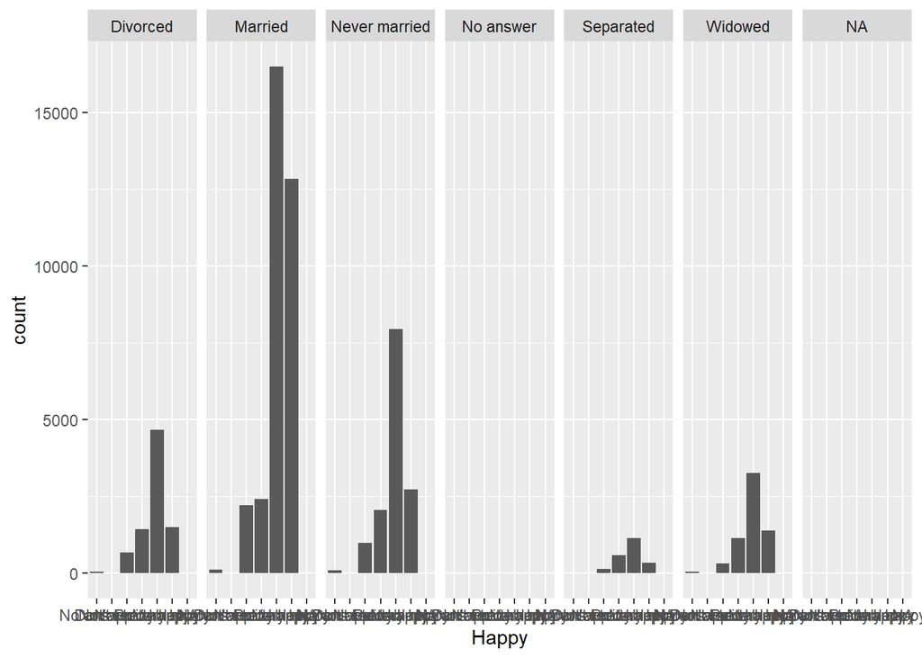

```r
library(readxl)
library(ggplot2)
library(ggmosaic)
dat <- read_xls("lab3.xls")
names(dat) <- c("Year","Happy","Party","Income1","Income2","Sex","Marital","Job","ID","Ballot")

#Problem 1
dat$Happy <- factor(dat$Happy, levels = c("No answer","Don't know","Not applicable","Not too happy","Pretty happy","Very happy"))
ggplot(dat,aes(x=Happy))+geom_bar()+facet_grid(~Marital)
```

Response: As can be seen from the graph, married people compared to the other groups are more in the categories of ‘pretty happy’ or ‘very happy’.

# Problem 2

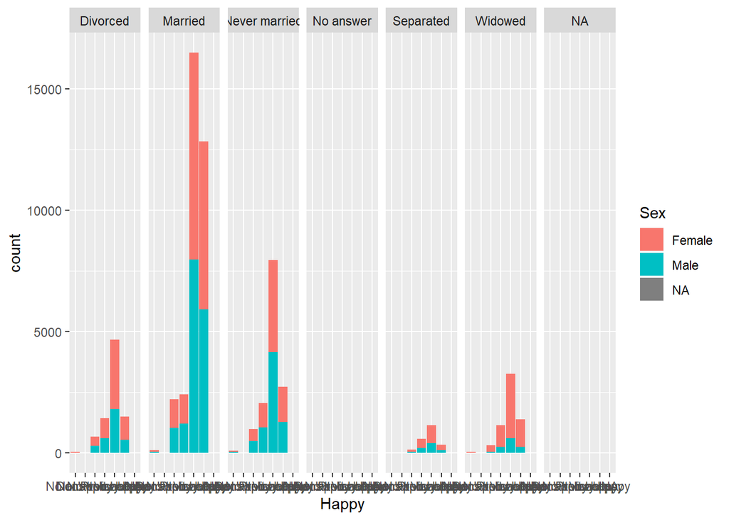

```r
ggplot(dat,aes(x=Happy,fill=Sex))+geom_bar()+facet_grid(~Marital)
```

# Problem 3

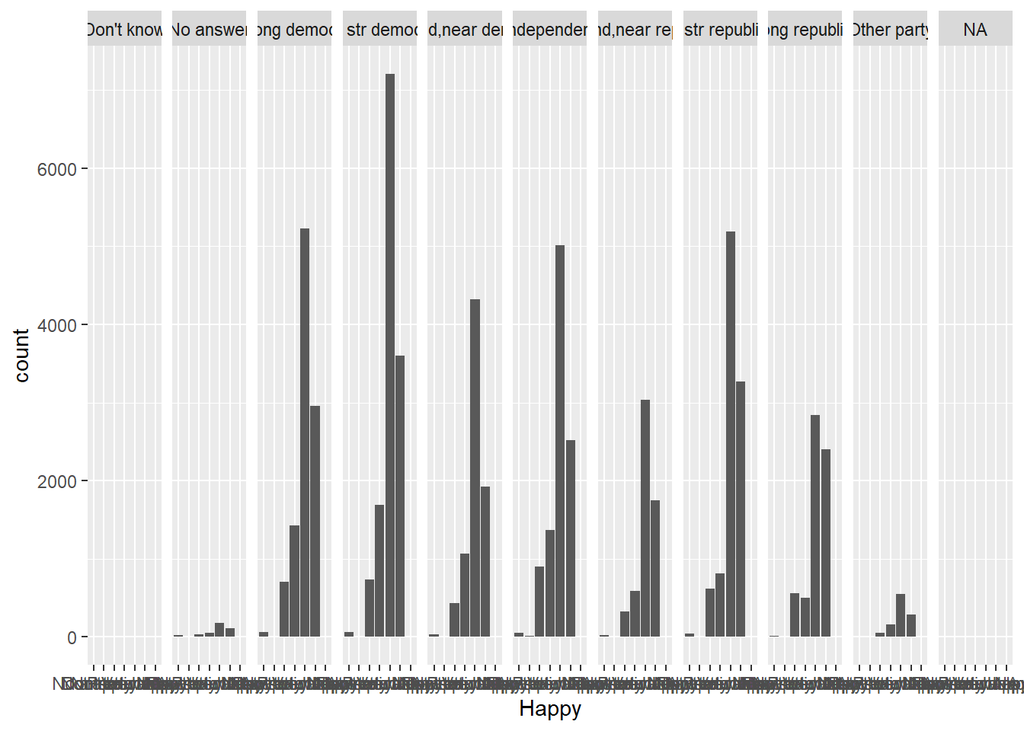

```r
dat$Party <- factor(dat$Party,levels=c("Don't know","No answer","Strong democrat","Not str democrat","Ind,near dem","Independent","Ind,near rep","Not str republican","Strong republican","Other party"))
ggplot(dat,aes(x=Happy))+geom_bar()+facet_grid(~Party)
```

# Problem 4

# a.How does income affect happiness?

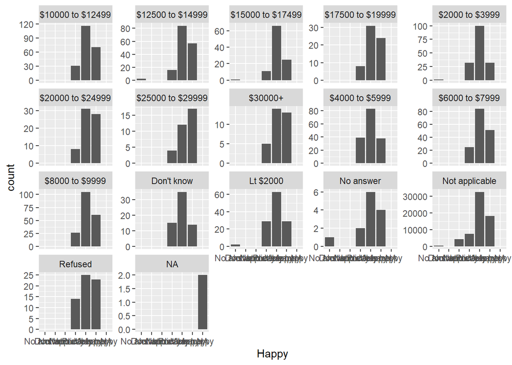

```r
ggplot(dat,aes(x=Happy))+geom_bar()+facet_wrap(~Income1,scales='free_y')
```

It does appear that the income of a person plays some role in the happiness of a person. Once the income gets above 20,000, it appears that there is a greater number of people answers very happy, mostly in place of not too happy. This appears to be the case all the way up through the income ranges.

# b. How does income affect party?

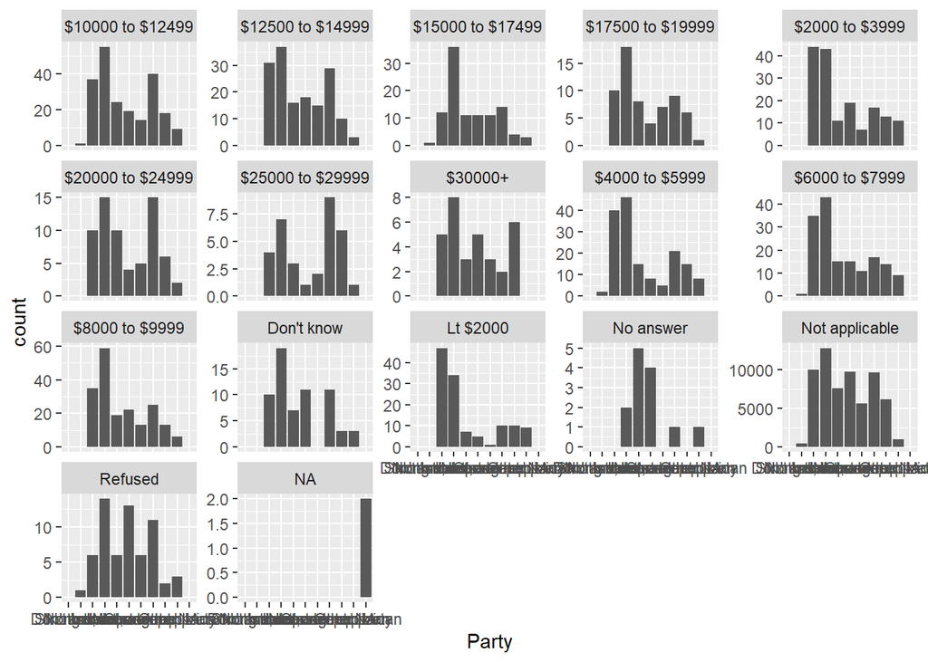

```r
ggplot(dat,aes(x=Party))+geom_bar()+facet_wrap(~Income1,scales='free_y')
```

When further investigating the question of party affecting income, we see that the plot is not very intuitive since there are too many people who lie in the Not Applicable category. With the data we can get, there appears to be more Democratic-leaning people in most of the plots.